# Sentiment Analysis of Amazon Customer Reviews

#### by Qiang (Jesse) Zhen

One of the hot-trend topics in Natural Language Processing (NLP) is sentiment analysis. Sentiment analysis involves extraction of subjective information from documents like posts and reviews to determine the opinion with respect to products, service, events, or ideas.

This project uses the customer review data from Amazon.com to perform a supervised binary (positive or negative) sentiment classification analysis. We use various data pre-processing techniques and demonstrate their effectiveness in improving the classification. We also compare three machine learning models, namely, the multinomial Naive Bayes classification model (MultinomialNB), the Logistic regression model (LogisticRegression), and the linear support vector classification model (LinearSVC).

**Table of Contents**

- 1. Data Understanding
  - 1.1 Import modulus
  - 1.2 Load data
  - 1.3 Generate the sentiment label
  - 1.4 Select the required columns
- 2. Data Preparation
  - 2.1 Under-sampling
  - 2.2 Data preprocessing
  - 2.3 Split dataset to training, validation, and test sets
- 3. Feature Extraction
  - 3.1 Compute the frequency of words
  - 3.2 Vectorizer and Tf–idf term weighting
  - 3.3 Feature Extraction
- 4. Basic Modeling
  - 4.1 Multinomial Naive Bayes classification model (MultinomialNB)
  - 4.2 Logistic clssification model (LogisticRegression)
  - 4.3 Linear support vector classification model (LinearSVC)
- 5. Fine-tuning the Number of Features
  - 5.1 Define the training function
  - 5.2 Fine-tuning MultinomialNB
  - 5.3 Fine-tuning LogisticRegression
  - 5.4 Fine-tuning LinearSVC
  - 5.5 Summary of the three models
- 6. Grid Search for Parameter Tuning
  - 6.1 Grid search on MultinomialNB
  - 6.2 Grid search on LogisticRegression
  - 6.3 Grid search on LinearSVC
- 7. Model Accuracy on the Test Set
  - 7.1 MultinomialNB model accuracy
  - 7.2 LogisticRegression model accuracy
  - 7.3 LinearSVC model accuracy
- 8. Prediction on New Entries
- 9. Model Output
- 10. Web Application
- 11. Ending Discussion

## 1. Data Understanding

### 1.1 Import modulus

```python
# user definded function to indicate processing progress
import my_utils

import html
import time
import functools
import pandas as pd
import numpy as np
import nltk
from nltk.corpus import stopwords as sw
import string
import matplotlib.pyplot as plt
%matplotlib inline

from sklearn.feature_extraction.text import CountVectorizer, TfidfTransformer, TfidfVectorizer
from sklearn.model_selection import train_test_split
from sklearn import metrics
from sklearn.naive_bayes import MultinomialNB
from sklearn.svm import LinearSVC
from sklearn.linear_model import LogisticRegression

import pickle
```

### 1.2 Load data

The data comes from the website "Amazon product data" managed by Dr. Julian McAuley from UCSD. We choose the smaller subset of the customer review data from the Kindle store of Amazon.com. The data is in the JSON format, which contains 982,619 reviews and metadata spanning May 1996 - July 2014.

- Data source: Amazon product data, by Julian McAuley, UCSD
  - http://jmcauley.ucsd.edu/data/amazon/
- The kindle store review data from Amazon is used in this project
  - http://snap.stanford.edu/data/amazon/productGraph/categoryFiles/reviews_Kindle_Store_5.json.gz

```python
import json
data = pd.read_json('Kindle_Store_5.json', lines=True)
```

```python
data.head()
```

|  | asin | helpful | overall | reviewText | reviewTime | reviewerID | reviewerName | summary | unixReviewTime |
| --- | --- | --- | --- | --- | --- | --- | --- | --- | --- |
| 0 | B000F83SZQ | [0, 0] | 5 | I enjoy vintage books and movies so I enjoyed ... | 05 5, 2014 | A1F6404F1VG29J | Avidreader | Nice vintage story | 1399248000 |
| 1 | B000F83SZQ | [2, 2] | 4 | This book is a reissue of an old one; the auth... | 01 6, 2014 | AN0N05A9LIJEQ | critters | Different... | 1388966400 |
| 2 | B000F83SZQ | [2, 2] | 4 | This was a fairly interesting read. It had ol... | 04 4, 2014 | A795DMNCJILA6 | dot | Oldie | 1396569600 |
| 3 | B000F83SZQ | [1, 1] | 5 | I'd never read any of the Amy Brewster mysteri... | 02 19, 2014 | A1FV0SX13TWVXQ | Elaine H. Turley "Montana Songbird" | I really liked it. | 1392768000 |
| 4 | B000F83SZQ | [0, 1] | 4 | If you like period pieces - clothing, lingo, y... | 03 19, 2014 | A3SPTOKDG7WBLN | Father Dowling Fan | Period Mystery | 1395187200 |

### 1.3 Generate the sentiment label

Reviews with overall rating of 1, 2, or 3 are labeled as negative ("neg"), and reviews with overall rating of 4 or 5 are labeled as positive ("pos").

- Make a new column named 'pos_neg':
  - pos_neg = 'neg' when overall=1, 2 ,or 3,
  - pos_neg = 'pos' when overall=4 or 5

```python
data.columns.values
```

```
array(['asin', 'helpful', 'overall', 'reviewText', 'reviewTime',
       'reviewerID', 'reviewerName', 'summary', 'unixReviewTime'], dtype=object)
```

```python
# Make a new column named 'pos_neg', which has value 'neg' if the overall rating is 1, 2 ,or 3,
# and has value 'pos' of the overall rating is 4 or 5.
data.loc[data.overall.isin([1,2,3]), 'pos_neg'] = 'neg'
data.loc[data.overall.isin([4,5]), 'pos_neg'] = 'pos'
```

### 1.4 Select the required columns

- Choose only the columns 'pop_neg' and 'reviewText'

```python
# Choose only the columns 'pop_neg' and 'reviewText'
df = data[['pos_neg', 'reviewText']]
```

```python
df.head()
```

|  | pos_neg | reviewText |
| --- | --- | --- |
| 0 | pos | I enjoy vintage books and movies so I enjoyed ... |
| 1 | pos | This book is a reissue of an old one; the auth... |
| 2 | pos | This was a fairly interesting read. It had ol... |
| 3 | pos | I'd never read any of the Amy Brewster mysteri... |
| 4 | pos | If you like period pieces - clothing, lingo, y... |

## 2. Data Preparation

### 2.1 Under-sampling

Since the dataset is imbalanced that more than 84% of the reviews are positive, we undersample the positive reviews (the majority class) to have exactly the same number of reviews as in the negative ones.

```python
# Check whethere there is any missing data
df.isnull().sum()
```

```
pos_neg       0
reviewText    0
dtype: int64
```

```python
data.shape
```

```
(982619, 10)
```

```python
# Check the distribution of the positive and negative reviews
df.pos_neg.value_counts()
```

```
pos    829277
neg    153342
Name: pos_neg, dtype: int64
```

```python
# Sample positive reveiws to get a balanced dataset
neg = df.loc[df.pos_neg=='neg']
pos = df.loc[df.pos_neg=='pos'].sample(n=df.pos_neg.value_counts()['neg'], random_state=42)
```

```python
print(type(pos))
print("pos:", len(pos), ", neg:", len(neg))
```

```
<class 'pandas.core.frame.DataFrame'>
pos: 153342 , neg: 153342
```

### 2.2 Data preprocessing

Data preprocessing process uses the following steps:

- Use HTMLParser to un-escape the text
- Change "can't" to "can not", and change "n't" to "not" (This is useful for the negation handling process)
- Pad punctuations with blanks
  - Note: if choosing not to perform negation handling, then directly remove punctuations
- Word normalization: lowercase every word
- Word tokenization
- Perform **negation handling**
  - A major problem faced during sentiment analysis is to handle negations.
  - The algorithm used here comes from Narayanan, Arora, and Bhatia's paper "*Fast and accurate sentiment classification using an enhanced Naive Bayes model*" [(link)](https://arxiv.org/abs/1305.6143)
  - The algorithm:
    - Use a state variable to store the negation state
    - Transform a word followed by a "not" or "no" into “not_” + word
    - Whenever the negation state variable is set, the words read are treated as “not_” + word
    - The state variable is reset when a punctuation mark is encountered or when there is double negation
- Use **bigram** and/or **trigram** models
  - Information about sentiment is often conveyed by adjectives ore more specifically by certain combinations of adjectives.
  - This information can be captured by adding features like consecutive pairs of words (bigrams) or even triplets of words (trigrams).
- Remove stopwords (optional)
- Word lemmatization

#### 2.2.1 Define the preprocessing function

```python
lemmatizer = nltk.WordNetLemmatizer()
stopwords = sw.words('english')
stopwords = stopwords + ['not_' + w for w in stopwords]

# transform punctuation to blanks
trans_punct = str.maketrans(string.punctuation,' '*len(string.punctuation))

# pad punctuation with blanks
pad_punct = str.maketrans({key: " {0} ".format(key) for key in string.punctuation})
# remove "_" from string.punctuation
invalidChars = str(string.punctuation.replace("_", ""))
```

```python
def preprocessing(line, ngram=1, neg_handling=True, remove_stop=False):
    """
    Preprocessing the review texts
    @params:
        line                       - Required: the input text (Str)
        ngram                  - Optional: number n in the n-gram model(Int, 1, 2, or 3)
        neg_handling       - Optional: whether to perform negation handling (Boolean)
        remove_stop        -Optional: whether to remove the stop words (Boolean)
    """

    line = html.unescape(str(line))
    line = str(line).replace("can't", "can not")
    line = str(line).replace("n't", " not")

    if neg_handling:
        line = str(line).translate(pad_punct)  # If performing negation handling, pad punctuations with blanks
        line = nltk.word_tokenize(line.lower()) # Word normalization and tokenization
        tokens = []
        negated = False
        for t in line:
            if t in ['not', 'no']:
                negated = not negated
            elif t in string.punctuation or not t.isalpha():
                negated = False
            else:
                tokens.append('not_' + t if negated else t)  # add "not_" prefix to words behind "not", or "no"
    else:
        line = str(line).translate(trans_punct)  # If not performing negation handling, remove punctuations
        line = nltk.word_tokenize(line.lower()) # Word normalization and tokenization
        tokens = line

    if ngram==2:
        bi_tokens = list(nltk.bigrams(line))
        bi_tokens = list(map('_'.join, bi_tokens))
        bi_tokens = [i for i in bi_tokens if all(j not in invalidChars for j in i)]
        tokens = tokens + bi_tokens

    if ngram==3:
        bi_tokens = list(nltk.bigrams(line))
        bi_tokens = list(map('_'.join, bi_tokens))
        bi_tokens = [i for i in bi_tokens if all(j not in invalidChars for j in i)]
        tri_tokens = list(nltk.trigrams(line))
        tri_tokens = list(map('_'.join, tri_tokens))
        tri_tokens = [i for i in tri_tokens if all(j not in invalidChars for j in i)]
        tokens = tokens + bi_tokens + tri_tokens

    if remove_stop:
        line = [lemmatizer.lemmatize(t) for t in tokens if t not in stopwords]
    else:
        line = [lemmatizer.lemmatize(t) for t in tokens]

    return ' '.join(line)
```

#### 2.2.2 An example

```python
line = "I don't think this book has any decent information!!! It is full of typos and factual errors that I can't ignore."
```

```python
preprocessing(line, ngram=1, neg_handling=False, remove_stop=False)
```

```
'i do not think this book ha any decent information it is full of typo and factual error that i can not ignore'
```

```python
preprocessing(line, ngram=1, neg_handling=False, remove_stop=True)
```

```
'think book decent information full typo factual error ignore'
```

```python
preprocessing(line, ngram=1, neg_handling=True, remove_stop=False)
```

```
'i do not_think not_this not_book not_has not_any not_decent not_information it is full of typo and factual error that i can not_ignore'
```

```python
preprocessing(line, ngram=3, neg_handling=True, remove_stop=False)
```

[output not shown]

#### 2.2.3 Preproessing the data

- Perform data preprocessing with negation handling, tri-gram modeling, without removing the stop words

```python
# Preprocessing the positive reveiws
pos_data = []
n_pos = len(pos)
for i, p in enumerate(pos['reviewText']):
    pos_data.append(preprocessing(p, ngram=3))
    my_utils.print_progress(bar_length=50, decimals=0, iteration=i+1, total=n_pos, prefix='Preprocessing pos data: ')
```

```
Preprocessing pos data:  |==================================================| 100%
```

```python
# Preprocessing the negative reveiws
neg_data = []
n_neg = len(neg)
for i, n in enumerate(neg['reviewText']):
    neg_data.append(preprocessing(n, ngram=3))
    my_utils.print_progress(bar_length=50, decimals=0, iteration=i+1, total=n_neg, prefix='Preprocessing neg data: ')
```

```
Preprocessing neg data:  |==================================================| 100%
```

```python
# Combine the preprocessed data
data = pos_data + neg_data
labels = np.concatenate((pos['pos_neg'].values, neg['pos_neg'].values))
```

### 2.3 Split dataset to training, validation, and test sets

We split the whole dataset randomly to the training set, validation set, and testing set by the proportion of 60%, 20%, and 20% respectively.

```python
# split the dataset to training, validation, test sets by 60-20-20
train_data, rest_data, train_labels, rest_labels = train_test_split(data, labels, test_size=0.4,
                                                                    stratify=labels, random_state=1234)
valid_data, test_data, valid_labels, test_labels = train_test_split(rest_data, rest_labels, test_size=0.5,
                                                                    stratify=rest_labels, random_state=1234)
print("training size = ", len(train_data), "validation size = ", len(valid_data), "testing size = ", len(test_data))
```

```
training size =  184010 validation size =  61337 testing size =  61337
```

## 3. Feature Extraction

We use vectorization process to turn the collection of text documents into numerical feature vectors. To extract numerical features from text content, we use the **Bag of Words** strategy:

- **tokenizing** strings and giving an integer id for each possible token, by using white-spaces as token separators
- **counting** the occurrences of tokens in each document
- **normalizing** and **tf-idf weighting** with diminishing importance tokens that occur in the majority of documents

A corpus of documents can thus be represented by a matrix with one row per document and one column per token (e.g. word) occurring in the corpus, while completely ignoring the relative position information of the words in the document.

### 3.1 Compute the frequency of words

```python
# Push all tokens and compute the frequency of words
tokens = [word for line in train_data for word in nltk.word_tokenize(line)]
word_features = nltk.FreqDist(tokens)
```

```python
print(word_features)
```

```
<FreqDist with 8128698 samples and 56232053 outcomes>
```

```python
# Print the 10 most common words
word_features.most_common(10)
```

```
[('the', 904966),
 ('a', 629222),
 ('and', 605310),
 ('i', 583304),
 ('to', 503199),
 ('is', 455444),
 ('of', 369937),
 ('it', 332547),
 ('this', 290662),
 ('wa', 271098)]
```

```python
# Remove features (words) which occur only once (This is to be used in the basic modeling process)
topwords = [fpair[0] for fpair in list(word_features.most_common(len(word_features))) if fpair[1]>=2]
len(topwords)
```

```
2029001
```

### 3.2 Vectorizer and Tf–idf term weighting

```python
# Convert a collection of raw documents to a matrix of TF-IDF features.
# Equivalent to CountVectorizer followed by TfidfTransformer.
tf_vec = TfidfVectorizer()

tf_vec.fit_transform([' '.join(topwords)])
```

```
<1x2027753 sparse matrix of type '<class 'numpy.float64'>'
	with 2027753 stored elements in Compressed Sparse Row format>
```

### 3.3 Feature Extraction

```python
# Extract features from training set
# Vocabulary is from topwords
train_features = tf_vec.transform(train_data)
```

```python
# Array[n_train_data * n_features]
train_features.shape
```

```
(184010, 2027753)
```

```python
# Extract features from test set
test_features = tf_vec.transform(test_data)
```

```python
test_features.shape
```

```
(61337, 2027753)
```

## 4. Basic Modeling

Next we demonstrate the effectiveness of negation handling and n-gram modeling techniques, and compare three machine learning algorithms, namely, the multinomial Naive Bayes classification model (MultinomialNB), the Logistic regression model (LogisticRegression), and the linear support vector classification model (LinearSVC).

As a basic feature selection procedure, we remove features/tokens which occur only once to avoid over-fitting. We also use the default penalty parameter in each machine learning algorithm.

The following table illustrates the model accuracy on the testing dataset by using different preprocessing procedures and different machine learning algorithms:

| Preprocessing procedure Added | Number of features/tokens | MultinomialNB | LogisticRegression | LinearSVC |
| --- | --- | --- | --- | --- |
| Basic preprocessing^ | 56,558 | 0.8329 | 0.8453 | 0.8485 |
| Adding negation handling | 71,853 | 0.8262 | 0.8519 | 0.8562 |
| Adding bigrams and trigrams | 2,027,753 | 0.8584 | 0.8675 | 0.8731 |

^ *Basic preprocessing* procedures include procedures with uni-gram modeling but without negation handling.

We omit the codes for model accuracy evaluation with basic preprocssing. In the rest of the code in this chapter, we perform the modeling processes based on the following data preprocessing and feature selection:

- Data preprocessing:
  - Negation handeling
  - Tri-gram modeling
  - Without removing stop words
- Feature selection:
  - Removing the features which occur only once
  - The remaining number of features is 2,029,001 (out of the total 8,128,698 features)

### 4.1 Multinomial Naive Bayes classification model (MultinomialNB)

```python
mnb_model = MultinomialNB()
mnb_model
```

```
MultinomialNB(alpha=1.0, class_prior=None, fit_prior=True)
```

```python
# Train Model
mnb_model.fit(train_features, train_labels)
```

```
MultinomialNB(alpha=1.0, class_prior=None, fit_prior=True)
```

```python
# Predict
pred = mnb_model.predict(test_features)
print(pred)
```

```
['neg' 'pos' 'pos' ... 'neg' 'pos' 'neg']
```

```python
# Metrics
accuracy = metrics.accuracy_score(test_labels, pred)
print(accuracy)
```

```
0.8583889006635473
```

```python
print(metrics.classification_report(y_true=test_labels, y_pred=pred, digits=4))
```

```
             precision    recall  f1-score   support

        neg     0.8560    0.8618    0.8589     30668
        pos     0.8608    0.8550    0.8579     30669

avg / total     0.8584    0.8584    0.8584     61337
```

### 4.2 Logistic regression model (LogisticRegression)

```python
lgr_model = LogisticRegression()
print(lgr_model, end='\n'*2)


lgr_model.fit(train_features, train_labels)
lgr_pred = lgr_model.predict(test_features)

print('Accuracy = %.5f' % metrics.accuracy_score(test_labels, lgr_pred))
print(metrics.classification_report(y_pred=lgr_pred, y_true=test_labels, digits=4))
```

```
LogisticRegression(C=1.0, class_weight=None, dual=False, fit_intercept=True,
          intercept_scaling=1, max_iter=100, multi_class='ovr', n_jobs=1,
          penalty='l2', random_state=None, solver='liblinear', tol=0.0001,
          verbose=0, warm_start=False)

Accuracy = 0.86749
             precision    recall  f1-score   support

        neg     0.8711    0.8626    0.8668     30668
        pos     0.8639    0.8724    0.8681     30669

avg / total     0.8675    0.8675    0.8675     61337
```

### 4.3 Linear support vector classification model (LinearSVC)

```python
svc_model = LinearSVC()
print(svc_model, end='\n'*2)

svc_model.fit(train_features, train_labels)
svc_pred = svc_model.predict(test_features)

print('Accuracy = %.5f' % metrics.accuracy_score(test_labels, svc_pred))
print(metrics.classification_report(y_pred=svc_pred, y_true=test_labels, digits=4))
```

```
LinearSVC(C=1.0, class_weight=None, dual=True, fit_intercept=True,
     intercept_scaling=1, loss='squared_hinge', max_iter=1000,
     multi_class='ovr', penalty='l2', random_state=None, tol=0.0001,
     verbose=0)

Accuracy = 0.87314
             precision    recall  f1-score   support

        neg     0.8798    0.8644    0.8720     30668
        pos     0.8667    0.8819    0.8742     30669

avg / total     0.8733    0.8731    0.8731     61337
```

## 5. Fine-tuning the Number of Features

The models trained in the above table come with a rather coarse feature selection procedure, that is, we simply remove features/tokens which occur only once.

To reach a better prediction power, we can fine-tune the number of features needed for each algorithm by using the validation dataset. Here we perform all of the preprocessing procedures, including negation handling and bigrams/trigrams modeling.

### 5.1 Define the training function

```python
def train_with_n_topwords(n, model_name='MultinomialNB', tfidf=True, valid=True, alpha=1.0):
    """
    Training the dataset using selected model and settings
    @params:
        n                       - Required: the number of features used to train the model (Int)
        model_name    - Optional: the model name('MultinomialNB' | 'LogisticRegression' | 'LinearSVC')
        tfidf                  - Optional: whether to perform the tfidf transformation (Boolean)
        valid                 - Optional: whether to use the validation set or the test set (Boolean)
        alpha                - Optional: the penalty parameter in the training model (Float)
    """

    if model_name not in ['MultinomialNB', 'LinearSVC', 'LogisticRegression']:
        print("Wrong model name.")
        return

    topwords = [fpair[0] for fpair in list(word_features.most_common(n))]

    if tfidf:
        vec = TfidfVectorizer()
    else:
        vec = CountVectorizer()

    vec.fit_transform([' '.join(topwords)])

    # Model
    if model_name == 'MultinomialNB':
        model = MultinomialNB(alpha=alpha)
    elif model_name == 'LinearSVC':
        model = LinearSVC(C=alpha)
    elif model_name == 'LogisticRegression':
        model = LogisticRegression(C=alpha)

    train_X = vec.transform(train_data)
    model.fit(train_X, train_labels)

    if valid:
        valid_X = vec.transform(valid_data)
        pred = model.predict(valid_X)
        metr = metrics.accuracy_score(valid_labels, pred)
    else:
        test_X = vec.transform(test_data)
        pred = model.predict(test_X)
        metr = metrics.accuracy_score(test_labels, pred)

    print("N of topwords:", n, "alpha:", alpha, "accuracy:", metr)
    return metr, vec, model
```

### 5.2 Fine-tuning MultinomialNB

```python
#MultinomialNB
possible_n = [100000 * i for i in range(1, 21)]

mnb_tfidf_accuracies = []

for i, n in enumerate(possible_n):
    metr = train_with_n_topwords(n, model_name='MultinomialNB')[0]
    mnb_tfidf_accuracies.append([n, metr])
```

```
N of topwords: 100000 alpha: 1.0 accuracy: 0.8542315405057307
N of topwords: 200000 alpha: 1.0 accuracy: 0.8564487992565661
N of topwords: 300000 alpha: 1.0 accuracy: 0.8567585633467565
N of topwords: 400000 alpha: 1.0 accuracy: 0.8571335409296184
N of topwords: 500000 alpha: 1.0 accuracy: 0.8572639679149616
N of topwords: 600000 alpha: 1.0 accuracy: 0.8576552488709914
N of topwords: 700000 alpha: 1.0 accuracy: 0.8577856758563347
N of topwords: 800000 alpha: 1.0 accuracy: 0.85789979946851
N of topwords: 900000 alpha: 1.0 accuracy: 0.857916102841678
N of topwords: 1000000 alpha: 1.0 accuracy: 0.8579650129611817
N of topwords: 1100000 alpha: 1.0 accuracy: 0.8579650129611817
N of topwords: 1200000 alpha: 1.0 accuracy: 0.8578182826026705
N of topwords: 1300000 alpha: 1.0 accuracy: 0.8578834960953421
N of topwords: 1400000 alpha: 1.0 accuracy: 0.8578182826026705
N of topwords: 1500000 alpha: 1.0 accuracy: 0.85789979946851
N of topwords: 1600000 alpha: 1.0 accuracy: 0.857916102841678
N of topwords: 1700000 alpha: 1.0 accuracy: 0.8577856758563347
N of topwords: 1800000 alpha: 1.0 accuracy: 0.8577041589904951
N of topwords: 1900000 alpha: 1.0 accuracy: 0.8578019792295026
N of topwords: 2000000 alpha: 1.0 accuracy: 0.8577693724831668
```

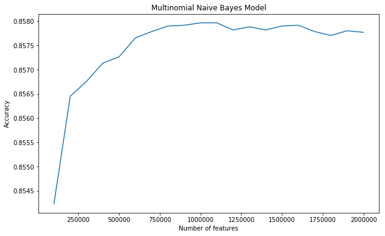

```python
mnb_accu = pd.DataFrame(mnb_tfidf_accuracies, columns=['topwords', 'accuracy'])
fig = plt.figure(figsize=(10,6))
plt.plot(mnb_accu.topwords, mnb_accu.accuracy, label='MultinomialNB')
#plt.legend()
plt.xlabel("Number of features")
plt.ylabel("Accuracy")
plt.title("Multinomial Naive Bayes Model")
fig.savefig("model_mnb_large_100k.png")
```

```python
mnb_accu[mnb_accu.accuracy==max(mnb_accu.accuracy)]
```

|  | topwords | accuracy |
| --- | --- | --- |
| 9 | 1000000 | 0.857965 |
| 10 | 1100000 | 0.857965 |

```python
best_n_topwords_mnb = mnb_accu[mnb_accu.accuracy==max(mnb_accu.accuracy)].iloc[0,0]
best_n_topwords_mnb
```

```
1000000
```

### 5.3 Fine-tuning LogisticRegression

```python
# Logistic
possible_n = [100000 * i for i in range(1, 21)]

lgr_tfidf_accuracies = []

for i, n in enumerate(possible_n):
    metr = train_with_n_topwords(n, model_name="LogisticRegression")[0]
    lgr_tfidf_accuracies.append([n, metr])
```

```
N of topwords: 100000 alpha: 1.0 accuracy: 0.8695730146567324
N of topwords: 200000 alpha: 1.0 accuracy: 0.8695567112835646
N of topwords: 300000 alpha: 1.0 accuracy: 0.8695567112835646
N of topwords: 400000 alpha: 1.0 accuracy: 0.8696219247762362
N of topwords: 500000 alpha: 1.0 accuracy: 0.8697034416420757
N of topwords: 600000 alpha: 1.0 accuracy: 0.8695404079103967
N of topwords: 700000 alpha: 1.0 accuracy: 0.869475194417725
N of topwords: 800000 alpha: 1.0 accuracy: 0.869475194417725
N of topwords: 900000 alpha: 1.0 accuracy: 0.8694262842982213
N of topwords: 1000000 alpha: 1.0 accuracy: 0.8694262842982213
N of topwords: 1100000 alpha: 1.0 accuracy: 0.8692958573128781
N of topwords: 1200000 alpha: 1.0 accuracy: 0.8692795539397101
N of topwords: 1300000 alpha: 1.0 accuracy: 0.8692795539397101
N of topwords: 1400000 alpha: 1.0 accuracy: 0.8691817337007027
N of topwords: 1500000 alpha: 1.0 accuracy: 0.8691654303275348
N of topwords: 1600000 alpha: 1.0 accuracy: 0.8691002168348632
N of topwords: 1700000 alpha: 1.0 accuracy: 0.8691165202080311
N of topwords: 1800000 alpha: 1.0 accuracy: 0.8690676100885273
N of topwords: 1900000 alpha: 1.0 accuracy: 0.8689697898495199
N of topwords: 2000000 alpha: 1.0 accuracy: 0.8688719696105124
```

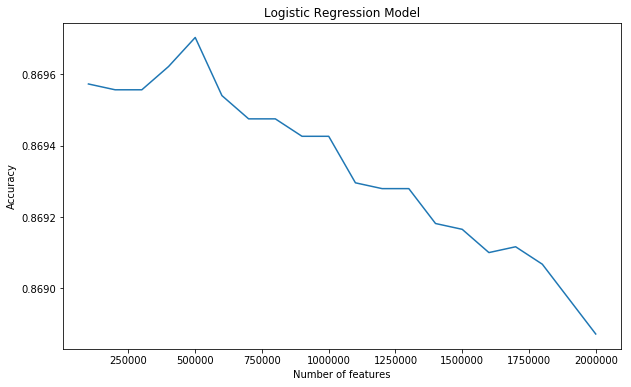

```python
lgr_accu = pd.DataFrame(lgr_tfidf_accuracies, columns=['topwords', 'accuracy'])
fig = plt.figure(figsize=(10,6))
plt.plot(lgr_accu.topwords, lgr_accu.accuracy, label='LogisticRegression')
#plt.legend()
plt.xlabel("Number of features")
plt.ylabel("Accuracy")
plt.title("Logistic Regression Model")
fig.savefig("model_lgr_large_100k.png")
```

```python
lgr_accu[lgr_accu.accuracy==max(lgr_accu.accuracy)]
```

|  | topwords | accuracy |
| --- | --- | --- |
| 4 | 500000 | 0.869703 |

```python
best_n_topwords_lgr = lgr_accu[lgr_accu.accuracy==max(lgr_accu.accuracy)].iloc[0,0]
best_n_topwords_lgr
```

```
500000
```

### 5.4 Fine-tuning LinearSVC

```python
# Linear SVC
possible_n = [100000 * i for i in range(1, 21)]

svc_tfidf_accuracies = []

for i, n in enumerate(possible_n):
    metr = train_with_n_topwords(n, model_name="LinearSVC")[0]
    svc_tfidf_accuracies.append([n, metr])
```

```
N of topwords: 100000 alpha: 1.0 accuracy: 0.8726217454391314
N of topwords: 200000 alpha: 1.0 accuracy: 0.8736814646950454
N of topwords: 300000 alpha: 1.0 accuracy: 0.8736325545755417
N of topwords: 400000 alpha: 1.0 accuracy: 0.8733227904853514
N of topwords: 500000 alpha: 1.0 accuracy: 0.8736651613218775
N of topwords: 600000 alpha: 1.0 accuracy: 0.873583644456038
N of topwords: 700000 alpha: 1.0 accuracy: 0.8738771051730603
N of topwords: 800000 alpha: 1.0 accuracy: 0.8740075321584035
N of topwords: 900000 alpha: 1.0 accuracy: 0.874105352397411
N of topwords: 1000000 alpha: 1.0 accuracy: 0.8741542625169147
N of topwords: 1100000 alpha: 1.0 accuracy: 0.8743172962485939
N of topwords: 1200000 alpha: 1.0 accuracy: 0.8743172962485939
N of topwords: 1300000 alpha: 1.0 accuracy: 0.8744803299802729
N of topwords: 1400000 alpha: 1.0 accuracy: 0.8745944535924483
N of topwords: 1500000 alpha: 1.0 accuracy: 0.8744803299802729
N of topwords: 1600000 alpha: 1.0 accuracy: 0.8744151164876013
N of topwords: 1700000 alpha: 1.0 accuracy: 0.8746107569656162
N of topwords: 1800000 alpha: 1.0 accuracy: 0.8744803299802729
N of topwords: 1900000 alpha: 1.0 accuracy: 0.8745129367266087
N of topwords: 2000000 alpha: 1.0 accuracy: 0.8744966333534409
```

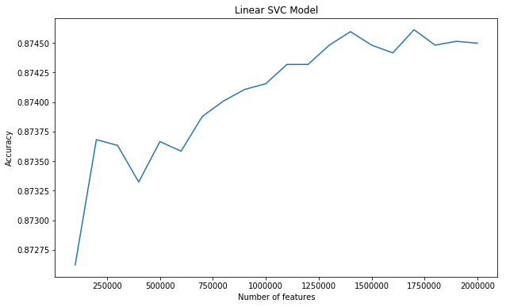

```python
svc_accu = pd.DataFrame(svc_tfidf_accuracies, columns=['topwords', 'accuracy'])
fig = plt.figure(figsize=(10,6))
plt.plot(svc_accu.topwords, svc_accu.accuracy, label='LinearSCV')
#plt.legend()
plt.xlabel("Number of features")
plt.ylabel("Accuracy")
plt.title("Linear SVC Model")
fig.savefig("model_svc_large_100k.png")
```

```python
svc_accu[svc_accu.accuracy==max(svc_accu.accuracy)]
```

|  | topwords | accuracy |
| --- | --- | --- |
| 16 | 1700000 | 0.874611 |

```python
best_n_topwords_svc = svc_accu[svc_accu.accuracy==max(svc_accu.accuracy)].iloc[0,0]
best_n_topwords_svc
```

```
1700000
```

### 5.5 Summary of the three models

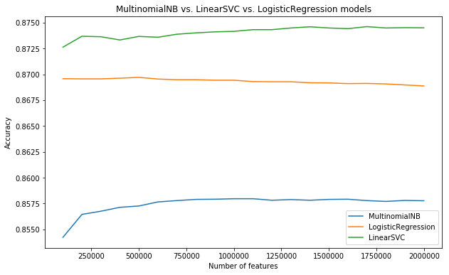

```python
fig = plt.figure(figsize=(10,6))
plt.plot(mnb_accu.topwords, mnb_accu.accuracy, label='MultinomialNB')
plt.plot(lgr_accu.topwords, lgr_accu.accuracy, label='LogisticRegression')
plt.plot(svc_accu.topwords, svc_accu.accuracy, label='LinearSVC')
plt.legend()
plt.xlabel("Number of features")
plt.ylabel("Accuracy")
plt.title("MultinomialNB vs. LinearSVC vs. LogisticRegression models")
fig.savefig("model_all3_large_100k.png")
```

A plot of **Model Accuracy vs Number of Features** is shown above. It clearly shows that LinearSVC has the highest accuracy consistently, with LogisticRegression the less, and MultinomialNB the least. The following table summarizes the best number of features and the model accuracy on validation set.

|  | MultinomialNB | LogisticRegression | LinearSVC |
| --- | --- | --- | --- |
| Best number of features | 1,000,000 | 500,000 | 1,700,000 |
| Accuracy on validation set | 0.8580 | 0.8697 | 0.8746 |

## 6. Grid Search for Parameter Tuning

To get a better accuaracy, we can perform grid search on the number of features and the penalty parameter at the same time.

### 6.1 Grid Search on MultinomialNB

```python
# MultinomialNB
mnb_grid_tfidf_accuracies = []

for n in [100000 * i for i in range(1, 21)]:
    for alpha in [0.1 * j for j in range(1, 11)]:
        metr = train_with_n_topwords(n, model_name="MultinomialNB", alpha=alpha)[0]
        mnb_grid_tfidf_accuracies.append([n, alpha, metr])
```

```python
mnb_grid_accu = pd.DataFrame(mnb_grid_tfidf_accuracies, columns=['topwords', 'alpha', 'accuracy'])
mnb_grid_accu[mnb_grid_accu.accuracy==max(mnb_grid_accu.accuracy)]
```

[output not shown]

### 6.2 Grid Search on LogisticRegression

```python
# Logistic
lgr_grid_tfidf_accuracies = []

for n in [100000 * i for i in range(1, 21)]:
    for alpha in [0.1 * j for j in range(1, 11)]:
        metr = train_with_n_topwords(n, model_name="LogisticRegression", alpha=alpha)[0]
        lgr_grid_tfidf_accuracies.append([n, alpha, metr])
```

```python
lgr_grid_accu = pd.DataFrame(lgr_grid_tfidf_accuracies, columns=['topwords', 'C', 'accuracy'])
lgr_grid_accu[lgr_grid_accu.accuracy==max(lgr_grid_accu.accuracy)]
```

[output not shown]

### 6.3 Grid Search on LinearSVC

As a simply demonstration and in order to save the training time, we select only the best number of features (based on penalty parameter C=1.0), and tune the penalty parameter C.

- Note: To get a better accuracy, we should tune the number of features and the penalty parameter at the same time.

```python
# Linear SVC
svc_grid_tfidf_accuracies = []

for n in [best_n_topwords_svc]:
    for alpha in [0.1 * j for j in range(1, 11)]:
        metr = train_with_n_topwords(n, model_name="LinearSVC", alpha=alpha)[0]
        svc_grid_tfidf_accuracies.append([n, alpha, metr])
```

```
N of topwords: 1700000 alpha: 0.1 accuracy: 0.8704207900614637
N of topwords: 1700000 alpha: 0.2 accuracy: 0.8755074424898511
N of topwords: 1700000 alpha: 0.30000000000000004 accuracy: 0.876241094282407
N of topwords: 1700000 alpha: 0.4 accuracy: 0.8763552178945824
N of topwords: 1700000 alpha: 0.5 accuracy: 0.8759639369385526
N of topwords: 1700000 alpha: 0.6000000000000001 accuracy: 0.8754911391166832
N of topwords: 1700000 alpha: 0.7000000000000001 accuracy: 0.8753444087581721
N of topwords: 1700000 alpha: 0.8 accuracy: 0.8750998581606534
N of topwords: 1700000 alpha: 0.9 accuracy: 0.8748390041899669
N of topwords: 1700000 alpha: 1.0 accuracy: 0.8746107569656162
```

```python
svc_grid_accu = pd.DataFrame(svc_grid_tfidf_accuracies, columns=['topwords', 'C', 'accuracy'])
svc_grid_accu[svc_grid_accu.accuracy==max(svc_grid_accu.accuracy)]
```

|  | topwords | C | accuracy |
| --- | --- | --- | --- |
| 3 | 1700000 | 0.4 | 0.876355 |

```python
best_alpha_svc = svc_grid_accu[svc_grid_accu.accuracy==max(svc_grid_accu.accuracy)].iloc[0,1]
best_alpha_svc
```

```
0.4
```

## 7. Model Accuracy on the Test Set

#### Summary: The model accuracy on testing set

|  | MultinomialNB | LogisticRegression | LinearSVC | LinearSVC(with penalty parameter 0.4) |
| --- | --- | --- | --- | --- |
| Best number of features | 1,000,000 | 500,000 | 1,700,000 | 1,700,000 |
| Accuracy on testing set | 0.8585 | 0.8682 | 0.8730 | 0.8742 |

### 7.1 MultinomialNB model accuracy

```python
# MultinomialNB model accuracy based on the default model penalty parameter alpha=1.0
mnb_accuarcy, mnb_vec, mnb_model = train_with_n_topwords(n=best_n_topwords_mnb, model_name="MultinomialNB", valid=False)
```

```
N of topwords: 1000000 alpha: 1.0 accuracy: 0.8584867209025547
```

### 7.2 LogisticRegression model accuracy

```python
# LogisticRegression model accuracy based on the default model penalty parameter C=1.0
lgr_accuarcy, lgr_vec, lgr_model = train_with_n_topwords(n=best_n_topwords_lgr, model_name="LogisticRegression", valid=False)
```

```
N of topwords: 500000 alpha: 1.0 accuracy: 0.8682035313106282
```

### 7.3 LinearSVC model accuracy

```python
# LinearSVC model accuracy based on the default model penalty parameter C=1.0
svc_accuarcy, svc_vec, svc_model = train_with_n_topwords(n=best_n_topwords_svc, model_name="LinearSVC", valid=False)
```

```
N of topwords: 1700000 alpha: 1.0 accuracy: 0.8729804196488253
```

```python
# LinearSVC model accuracy based on the tuned model penalty parameter C=0.4
svc_accuarcy, svc_vec, svc_model = train_with_n_topwords(n=best_n_topwords_svc, model_name="LinearSVC", valid=False,
                                                         alpha=best_alpha_svc)
```

```
N of topwords: 1700000 alpha: 0.4 accuracy: 0.8742357793827543
```

## 8. Prediction on New Entries

```python
def predict_new(text, model_name='LinearSVC'):
    """
    Predict the sentiment of the 'text'.
    @params:
        text                   - Required: the text to predict (Str)
        model_name    - Optional: the model name('LinearSVC' | 'MultinomialNB' | 'LogisticRegression')
    """

    sentence = preprocessing(text, ngram=3)
    if model_name == 'LinearSVC':
        features = svc_vec.transform([text])
        pred = svc_model.predict(features)
    elif model_name == 'MultinomialNB':
        features = mnb_vec.transform([text])
        pred = mnb_model.predict(features)
    elif model_name == 'LogisticRegression':
        features = lgr_vec.transform([text])
        pred = lgr_model.predict(features)

    return pred[0]
```

```python
# An example of new review text
review_text = 'This book seems to have some decent information, but it is full of typos and factual errors.'
```

```python
predict_new(review_text, model_name='MultinomialNB')
```

```
'neg'
```

```python
predict_new(review_text, model_name='LogisticRegression')
```

```
'neg'
```

```python
predict_new(review_text, model_name='LinearSVC')
```

```
'neg'
```

## 9. Model Output

Use module "pickle" to save the model for furture use.

```python
# Save the vectorizer
with open('tf_vec.pkl', 'wb') as pkl_file:
    pickle.dump(svc_vec, pkl_file)
```

```python
# Save the model
with open('svc_model.pkl', 'wb') as pkl_file:
    pickle.dump(svc_model, pkl_file)
```

## 10. Web Application

To demonstrate this project, we wrote a **flask** (a lightweight WSGI web application framework [[link]](http://flask.pocoo.org/)) web application. You can enter some review text and let the app analyze the sentiment of your entry. Have fun!

[NLP Sentiment Analysis App](http://jesseqz.pythonanywhere.com/)